# Q6

Q6：

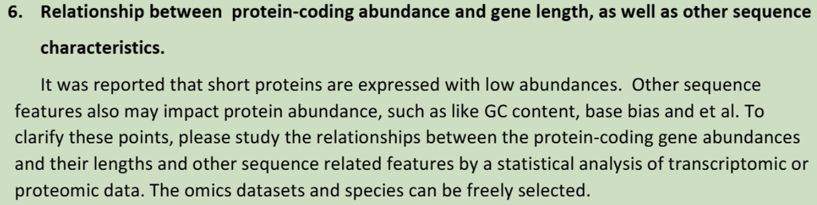

有报道称短蛋白的表达丰度较低。其他序列特征（如 GC 含量、碱基偏向性等）也可能影响蛋白丰度。需要通过统计分析转录组或蛋白质组数据，研究蛋白编码基因丰度与基因长度及其他序列相关特征之间的关系。可自由选择组学数据集和物种。

选择合适的物种和数据集，如常见的模式生物（小鼠、拟南芥等）或人类的转录组和蛋白质组数据。数据来源可以是公共数据库（如 ENCODE、PRIDE 等）或已发表的文献数据GEO。

### 数据预处理与特征提取 ：

- 基因丰度计算 ：从转录组数据中计算基因表达量（如使用 RPKM、FPKM 或 TPM 等指标），或者从蛋白质组数据中获取蛋白质丰度数据（如基于质谱的蛋白质绝对定量或相对定量数据）。
- 基因长度计算 ：根据基因组注释信息，提取每个蛋白编码基因的长度，包括 coding sequence（CDS）长度等。
- 其他序列特征计算 ：计算基因序列的 GC 含量（即序列中 G 和 C 碱基所占的比例）、碱基偏向性（如使用香农熵等指标衡量碱基分布的均匀性）等特征。

### 统计分析方法选择 ：

采用多元线性回归分析、相关性分析（如皮尔逊相关系数、斯皮尔曼秩相关系数）等方法，研究基因丰度与基因长度及其他序列特征之间的关系。例如，以基因丰度为因变量，基因长度、GC 含量、碱基偏向性等为自变量，建立多元线性回归模型，分析各自变量对因变量的影响程度和方向。

多元线性回归例：

log(Protein_Abundance) ~ log(Gene_Length) + GC_Content + Codon_Bias